# Session 2: Homework 1

Group A14

2020-09-27

# 1 Where Do People Drink The Most Beer, Wine And Spirits?

Back in 2014, [fivethiryeight.com](https://fivethirtyeight.com/features/dear-mona-followup-where-do-people-drink-the-most-beer-wine-and-spirits/) published an article on alchohol consumption in different countries. The data `drinks` is available as part of the `fivethirtyeight` package. Make sure you have installed the `fivethirtyeight` package before proceeding.

```r
library(fivethirtyeight)
data(drinks)
```

What are the variable types? Any missing values we should worry about?

```r
glimpse(drinks)
```

```
## Rows: 193
## Columns: 5
## $ country                      <chr> "Afghanistan", "Albania", "Algeria", "...
## $ beer_servings                <int> 0, 89, 25, 245, 217, 102, 193, 21, 261...
## $ spirit_servings              <int> 0, 132, 0, 138, 57, 128, 25, 179, 72, ...
## $ wine_servings                <int> 0, 54, 14, 312, 45, 45, 221, 11, 212, ...
## $ total_litres_of_pure_alcohol <dbl> 0.0, 4.9, 0.7, 12.4, 5.9, 4.9, 8.3, 3....
```

```r
skim(drinks)
```

Data summary

| Name | drinks |
| --- | --- |
| Number of rows | 193 |
| Number of columns | 5 |
| _______________________ |  |
| Column type frequency: |  |
| character | 1 |
| numeric | 4 |
| ________________________ |  |
| Group variables | None |

**Variable type: character**

| skim_variable | n_missing | complete_rate | min | max | empty | n_unique | whitespace |
| --- | --- | --- | --- | --- | --- | --- | --- |
| country | 0 | 1 | 3 | 28 | 0 | 193 | 0 |

**Variable type: numeric**

| skim_variable | n_missing | complete_rate | mean | sd | p0 | p25 | p50 | p75 | p100 | hist |
| --- | --- | --- | --- | --- | --- | --- | --- | --- | --- | --- |
| beer_servings | 0 | 1 | 106.16 | 101.14 | 0 | 20.0 | 76.0 | 188.0 | 376.0 | ▇▃▂▂▁ |
| spirit_servings | 0 | 1 | 80.99 | 88.28 | 0 | 4.0 | 56.0 | 128.0 | 438.0 | ▇▃▂▁▁ |
| wine_servings | 0 | 1 | 49.45 | 79.70 | 0 | 1.0 | 8.0 | 59.0 | 370.0 | ▇▁▁▁▁ |
| total_litres_of_pure_alcohol | 0 | 1 | 4.72 | 3.77 | 0 | 1.3 | 4.2 | 7.2 | 14.4 | ▇▃▅▃▁ |

No missing values, the variables are integers, character or double.

Make a plot that shows the top 25 beer consuming countries

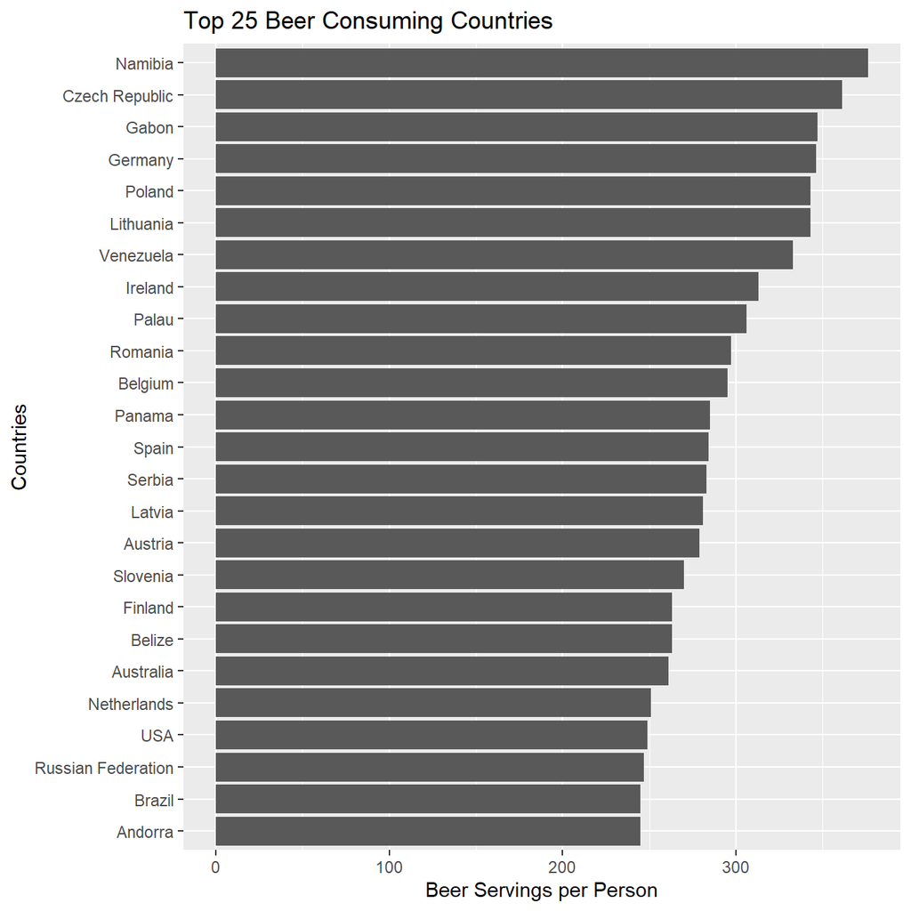

```r
Top25 <- drinks %>%
        slice_max(beer_servings, n=25)

ggplot(Top25, aes(x=reorder(country,beer_servings),y=beer_servings))+
      geom_bar(stat="identity")+
      coord_flip()+
     labs(y= "Beer Servings per Person", x = "Countries", title = "Top 25 Beer Consuming Countries")+
  NULL
```

Make a plot that shows the top 25 wine consuming countries

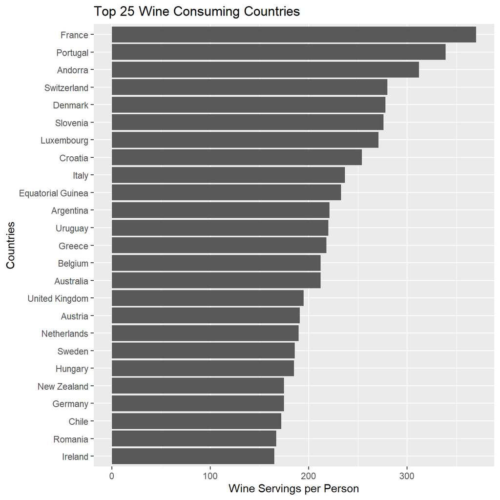

```r
Top25Wine <- drinks %>%
        slice_max(wine_servings, n=25)

ggplot(Top25Wine, aes(x=reorder(country,wine_servings),y=wine_servings))+
      geom_bar(stat="identity")+
      coord_flip()+
      labs(y= "Wine Servings per Person", x = "Countries", title = "Top 25 Wine Consuming Countries")+
  NULL
```

Finally, make a plot that shows the top 25 spirit consuming countries

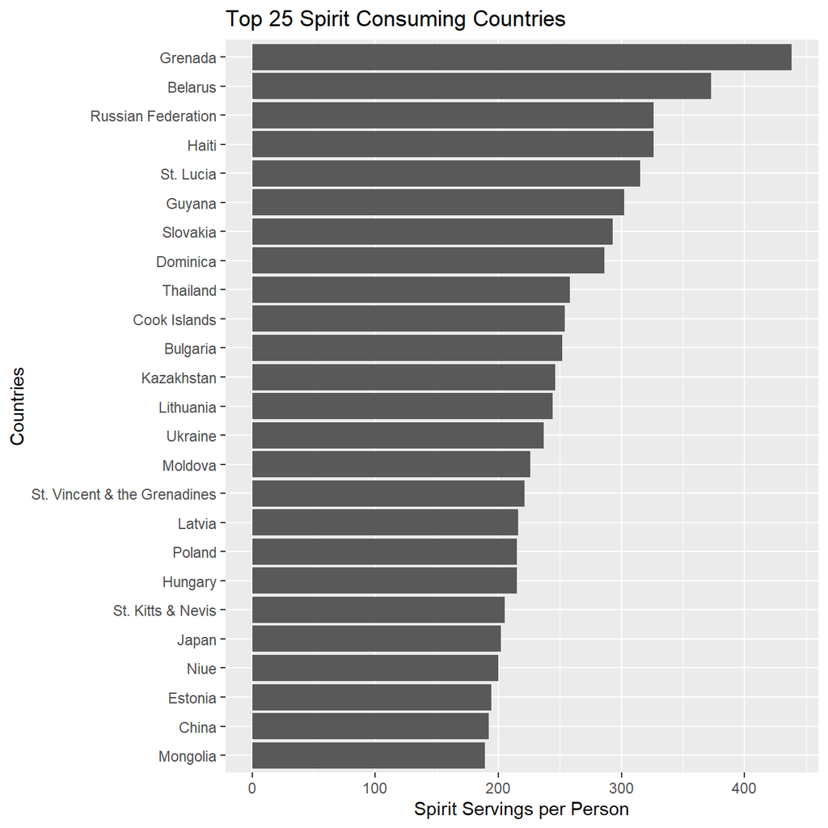

```r
Top25Spirit <- drinks %>%
        slice_max(spirit_servings, n=25)

ggplot(Top25Spirit,aes(x=reorder(country,spirit_servings),y=spirit_servings))+
      geom_bar(stat="identity")+
      coord_flip()+
      labs(y= "Spirit Servings per Person", x = "Countries", title = "Top 25 Spirit Consuming Countries")+
  NULL
```

What can you infer from these plots? Don’t just explain what’s in the graph, but speculate or tell a short story (1-2 paragraphs max).

Top consuming countries change according to the beverage, probably, it is due to cultural traditions and/or local production. For example, European countries are very famous due to wine production, so countries like Portugal and Italy appear as one of the top consumers, other countries from other continents such as Argentina and Chile, that produce a lot of wine, also appear as one of the top consumers. On the other hand, Germany and Brazil, countries that produce a lot of beer, are also one of the biggest beer consumers.

# 2 Analysis of movies- IMDB dataset

We will look at a subset sample of movies, taken from the [Kaggle IMDB 5000 movie dataset](https://www.kaggle.com/carolzhangdc/imdb-5000-movie-dataset)

```r
movies <- read_csv(here::here("data", "movies.csv"))
glimpse(movies)
```

```
## Rows: 2,961
## Columns: 11
## $ title               <chr> "Avatar", "Titanic", "Jurassic World", "The Ave...
## $ genre               <chr> "Action", "Drama", "Action", "Action", "Action"...
## $ director            <chr> "James Cameron", "James Cameron", "Colin Trevor...
## $ year                <dbl> 2009, 1997, 2015, 2012, 2008, 1999, 1977, 2015,...
## $ duration            <dbl> 178, 194, 124, 173, 152, 136, 125, 141, 164, 93...
## $ gross               <dbl> 7.61e+08, 6.59e+08, 6.52e+08, 6.23e+08, 5.33e+0...
## $ budget              <dbl> 2.37e+08, 2.00e+08, 1.50e+08, 2.20e+08, 1.85e+0...
## $ cast_facebook_likes <dbl> 4834, 45223, 8458, 87697, 57802, 37723, 13485, ...
## $ votes               <dbl> 886204, 793059, 418214, 995415, 1676169, 534658...
## $ reviews             <dbl> 3777, 2843, 1934, 2425, 5312, 3917, 1752, 1752,...
## $ rating              <dbl> 7.9, 7.7, 7.0, 8.1, 9.0, 6.5, 8.7, 7.5, 8.5, 7....
```

Besides the obvious variables of `title`, `genre`, `director`, `year`, and `duration`, the rest of the variables are as follows:

- `gross` : The gross earnings in the US box office, not adjusted for inflation
- `budget`: The movie’s budget
- `cast_facebook_likes`: the number of facebook likes cast memebrs received
- `votes`: the number of people who voted for (or rated) the movie in IMDB
- `reviews`: the number of reviews for that movie
- `rating`: IMDB average rating

## 2.1 Use your data import, inspection, and cleaning skills to answer the following:

- Are there any missing values (NAs)? Are all entries distinct or are there duplicate entries?

```r
glimpse(movies)
```

```
## Rows: 2,961
## Columns: 11
## $ title               <chr> "Avatar", "Titanic", "Jurassic World", "The Ave...
## $ genre               <chr> "Action", "Drama", "Action", "Action", "Action"...
## $ director            <chr> "James Cameron", "James Cameron", "Colin Trevor...
## $ year                <dbl> 2009, 1997, 2015, 2012, 2008, 1999, 1977, 2015,...
## $ duration            <dbl> 178, 194, 124, 173, 152, 136, 125, 141, 164, 93...
## $ gross               <dbl> 7.61e+08, 6.59e+08, 6.52e+08, 6.23e+08, 5.33e+0...
## $ budget              <dbl> 2.37e+08, 2.00e+08, 1.50e+08, 2.20e+08, 1.85e+0...
## $ cast_facebook_likes <dbl> 4834, 45223, 8458, 87697, 57802, 37723, 13485, ...
## $ votes               <dbl> 886204, 793059, 418214, 995415, 1676169, 534658...
## $ reviews             <dbl> 3777, 2843, 1934, 2425, 5312, 3917, 1752, 1752,...
## $ rating              <dbl> 7.9, 7.7, 7.0, 8.1, 9.0, 6.5, 8.7, 7.5, 8.5, 7....
```

```r
skim(movies)
```

Data summary

| Name | movies |
| --- | --- |
| Number of rows | 2961 |
| Number of columns | 11 |
| _______________________ |  |
| Column type frequency: |  |
| character | 3 |
| numeric | 8 |
| ________________________ |  |
| Group variables | None |

**Variable type: character**

| skim_variable | n_missing | complete_rate | min | max | empty | n_unique | whitespace |
| --- | --- | --- | --- | --- | --- | --- | --- |
| title | 0 | 1 | 1 | 83 | 0 | 2907 | 0 |
| genre | 0 | 1 | 5 | 11 | 0 | 17 | 0 |
| director | 0 | 1 | 3 | 32 | 0 | 1366 | 0 |

**Variable type: numeric**

| skim_variable | n_missing | complete_rate | mean | sd | p0 | p25 | p50 | p75 | p100 | hist |
| --- | --- | --- | --- | --- | --- | --- | --- | --- | --- | --- |
| year | 0 | 1 | 2.00e+03 | 9.95e+00 | 1920.0 | 2.00e+03 | 2.00e+03 | 2.01e+03 | 2.02e+03 | ▁▁▁▂▇ |
| duration | 0 | 1 | 1.10e+02 | 2.22e+01 | 37.0 | 9.50e+01 | 1.06e+02 | 1.19e+02 | 3.30e+02 | ▃▇▁▁▁ |
| gross | 0 | 1 | 5.81e+07 | 7.25e+07 | 703.0 | 1.23e+07 | 3.47e+07 | 7.56e+07 | 7.61e+08 | ▇▁▁▁▁ |
| budget | 0 | 1 | 4.06e+07 | 4.37e+07 | 218.0 | 1.10e+07 | 2.60e+07 | 5.50e+07 | 3.00e+08 | ▇▂▁▁▁ |
| cast_facebook_likes | 0 | 1 | 1.24e+04 | 2.05e+04 | 0.0 | 2.24e+03 | 4.60e+03 | 1.69e+04 | 6.57e+05 | ▇▁▁▁▁ |
| votes | 0 | 1 | 1.09e+05 | 1.58e+05 | 5.0 | 1.99e+04 | 5.57e+04 | 1.33e+05 | 1.69e+06 | ▇▁▁▁▁ |
| reviews | 0 | 1 | 5.03e+02 | 4.94e+02 | 2.0 | 1.99e+02 | 3.64e+02 | 6.31e+02 | 5.31e+03 | ▇▁▁▁▁ |
| rating | 0 | 1 | 6.39e+00 | 1.05e+00 | 1.6 | 5.80e+00 | 6.50e+00 | 7.10e+00 | 9.30e+00 | ▁▁▆▇▁ |

```r
newmovies <- movies %>%
  distinct(title,.keep_all = TRUE)
```

There are some duplicate entries, therefore, some movies appear twice and we deleted them. - Produce a table with the count of movies by genre, ranked in descending order

```r
genrecount <- newmovies %>%
              count(genre) %>%
              arrange(desc(n))
genrecount
```

```
## # A tibble: 17 x 2
##    genre           n
##    <chr>       <int>
##  1 Comedy        844
##  2 Action        719
##  3 Drama         484
##  4 Adventure     281
##  5 Crime         198
##  6 Biography     135
##  7 Horror        128
##  8 Animation      35
##  9 Fantasy        26
## 10 Documentary    25
## 11 Mystery        15
## 12 Sci-Fi          7
## 13 Family          3
## 14 Musical         2
## 15 Romance         2
## 16 Western         2
## 17 Thriller        1
```

- Produce a table with the average gross earning and budget (`gross` and `budget`) by genre. Calculate a variable `return_on_budget` which shows how many $ did a movie make at the box office for each $ of its budget. Ranked genres by this `` in descending order

```r
CountMovies <- newmovies %>%
               group_by(genre) %>%
               summarise(meangross = mean(gross),meanbudget = mean(budget))
               CountMovies$return_on_budget <- CountMovies$meangross/CountMovies$meanbudget
               CountMovies <- arrange(CountMovies,desc(return_on_budget))
CountMovies
```

```
## # A tibble: 17 x 4
##    genre        meangross meanbudget return_on_budget
##    <chr>            <dbl>      <dbl>            <dbl>
##  1 Musical      92084000    3189500          28.9
##  2 Family      149160478.  14833333.         10.1
##  3 Western      20821884    3465000           6.01
##  4 Documentary  17353973.   5887852.          2.95
##  5 Horror       37782310.  13804379.          2.74
##  6 Fantasy      41902674.  18484615.          2.27
##  7 Comedy       42487808.  24458506.          1.74
##  8 Mystery      69117136.  41500000           1.67
##  9 Animation    98433792.  61701429.          1.60
## 10 Biography    45201805.  28543696.          1.58
## 11 Adventure    94350236.  64692313.          1.46
## 12 Drama        36754959.  25832605.          1.42
## 13 Crime        37601525.  26527405.          1.42
## 14 Romance      31264848.  25107500           1.25
## 15 Action       86270343.  70774558.          1.22
## 16 Sci-Fi       29788371.  27607143.          1.08
## 17 Thriller         2468     300000           0.00823
```

- Produce a table that shows the top 15 directors who have created the highest gross revenue in the box office. Don’t just show the total gross amount, but also the mean, median, and standard deviation per director.

```r
TopDirectors <- newmovies%>%
                group_by(director) %>%
                summarise(GrossCreated = sum(gross), AvgGross = mean(gross), MedianGross = median(gross),SDgross =  StdDev(gross)) %>%
                arrange(desc(GrossCreated))
TopDirectors
```

```
## # A tibble: 1,366 x 5
##    director          GrossCreated   AvgGross MedianGross SDgross[,1]
##    <chr>                    <dbl>      <dbl>       <dbl>       <dbl>
##  1 Steven Spielberg    4014061704 174524422.  164435221   101421051.
##  2 Michael Bay         2195443511 182953626.  168468240.  125789167.
##  3 James Cameron       1909725910 318287652.  175562880.  309171337.
##  4 Christopher Nolan   1813227576 226653447   196667606.  187224133.
##  5 George Lucas        1741418480 348283696   380262555   146193880.
##  6 Robert Zemeckis     1619309108 124562239.  100853835    91300279.
##  7 Tim Burton          1557078534 111219895.   69791834    99304293.
##  8 Sam Raimi           1443167519 180395940.  138480208   174705230.
##  9 Clint Eastwood      1378321100  72543216.   46700000    75487408.
## 10 Francis Lawrence    1358501971 271700394.  281666058   135437020.
## # ... with 1,356 more rows
```

- Finally, ratings. Produce a table that describes how ratings are distributed by genre. We don’t want just the mean, but also, min, max, median, SD and some kind of a histogram or density graph that visually shows how ratings are distributed.

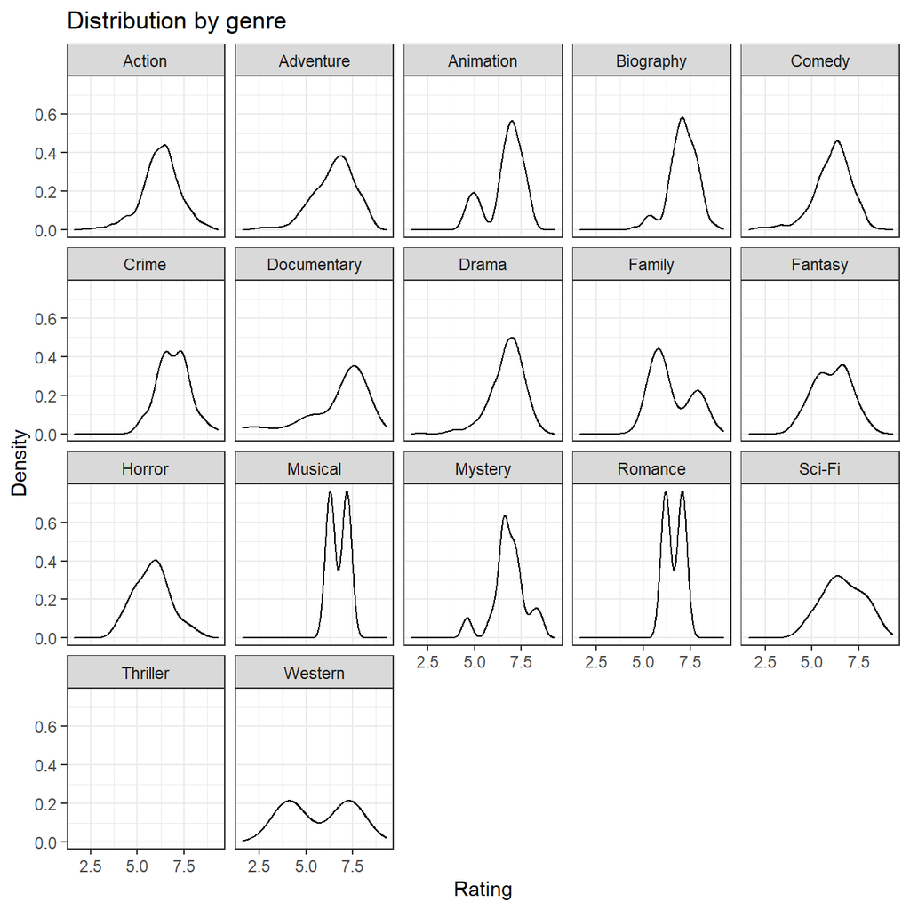

```r
Ratings <- newmovies%>%
           group_by(genre) %>%
           summarise(AvgRating = mean(rating), MedianRating = median(rating),SDRating = StdDev(rating), Minrating = min(rating), Maxrating = max(rating)) %>%
          arrange(desc(AvgRating))

ggplot(newmovies, aes(x = rating))+
      facet_wrap(~genre)+
      geom_density(alpha = 0.5)+
      labs(title = "Distribution by genre", x="Rating", y="Density") +
      theme_bw()
```

## Use `ggplot` to answer the following

- Examine the relationship between `gross` and `cast_facebook_likes`. Produce a scatterplot and write one sentence discussing whether the number of facebook likes that the cast has received is likely to be a good predictor of how much money a movie will make at the box office. What variable are you going to map to the Y- and X- axes?

[figure not shown]

```r
ggplot(newmovies, aes(x=cast_facebook_likes, y=gross)) +
    geom_point(shape=1) +
    geom_smooth(method=lm)+
    labs(title = "Revenue vs facebook likes", x="Facebook likes", y="Gross Revenue")
```

```r
cor( x = newmovies$cast_facebook_likes, y= newmovies$gross )
```

```
## [1] 0.208
```

Analyzing the graph, the variables are spread out across the graph, therefore, the number of facebook likes does not seem to influence a movie’s gross revenue success. To make sure about it, we calculated the correlation between then and we confirmed that the correlation is low.

- Examine the relationship between `gross` and `budget`. Produce a scatterplot and write one sentence discussing whether budget is likely to be a good predictor of how much money a movie will make at the box office.

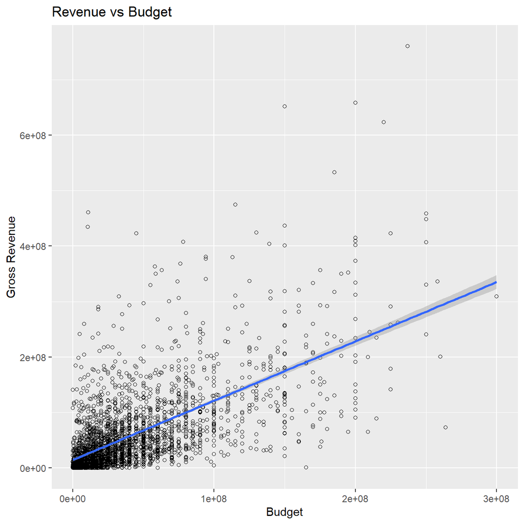

```r
ggplot(newmovies, aes(x=budget, y=gross)) +
    geom_point(shape=1) +
    geom_smooth(method=lm)+
    labs(title = "Revenue vs Budget", x="Budget", y="Gross Revenue")
```

```r
cor( x = newmovies$budget, y= newmovies$gross )
```

```
## [1] 0.639
```

```
The relation between `gross` and `budget` is positive, therefore, movies with a higher budget tend to have a higher gross, which is understandable, especially if a part of that higher budget is used as Advertisement Expense.
```

- Examine the relationship between `gross` and `rating`. Produce a scatterplot, faceted by `genre` and discuss whether IMDB ratings are likely to be a good predictor of how much money a movie will make at the box office. Is there anything strange in this dataset?

[figure not shown]

```r
ggplot(newmovies, aes(x=gross, y=rating)) +
    labs(title = "Revenue vs rating", x="Rating", y="Gross revenue") +
    geom_point(shape=1) +
    facet_wrap(~genre)+
    geom_smooth(method=lm)+
     theme_bw()
```

Most genre seem to have a positive relation between rating and gross revenue, which means that higher ratings tend to lead to a higer revenue. But, Documentary presents a negative correlation, so higher rating tend to decrease gross revenue. Other genres like Thriller, Western and Family do not have enough datapoints and we cannot identify a trend.

# 3 Returns of financial stocks

> You may find useful the material on [finance data sources](https://mfa2021.netlify.app/reference/finance_data/).

We will use the `tidyquant` package to download historical data of stock prices, calculate returns, and examine the distribution of returns.

We must first identify which stocks we want to download data for, and for this we must know their ticker symbol; Apple is known as AAPL, Microsoft as MSFT, McDonald’s as MCD, etc. The file `nyse.csv` contains 508 stocks listed on the NYSE, their ticker `symbol`, `name`, the IPO (Initial Public Offering) year, and the sector and industry the company is in.

```r
nyse <- read_csv(here::here("data","nyse.csv"))
```

Based on this dataset, create a table and a bar plot that shows the number of companies per sector, in descending order

```r
#table
by_sector <- nyse %>%
 group_by(sector) %>%
 summarize(count = n())

by_sector %>%
 arrange(desc(count))
```

```
## # A tibble: 12 x 2
##    sector                count
##    <chr>                 <int>
##  1 Finance                  97
##  2 Consumer Services        79
##  3 Public Utilities         60
##  4 Capital Goods            45
##  5 Health Care              45
##  6 Energy                   42
##  7 Technology               40
##  8 Basic Industries         39
##  9 Consumer Non-Durables    31
## 10 Miscellaneous            12
## 11 Transportation           10
## 12 Consumer Durables         8
```

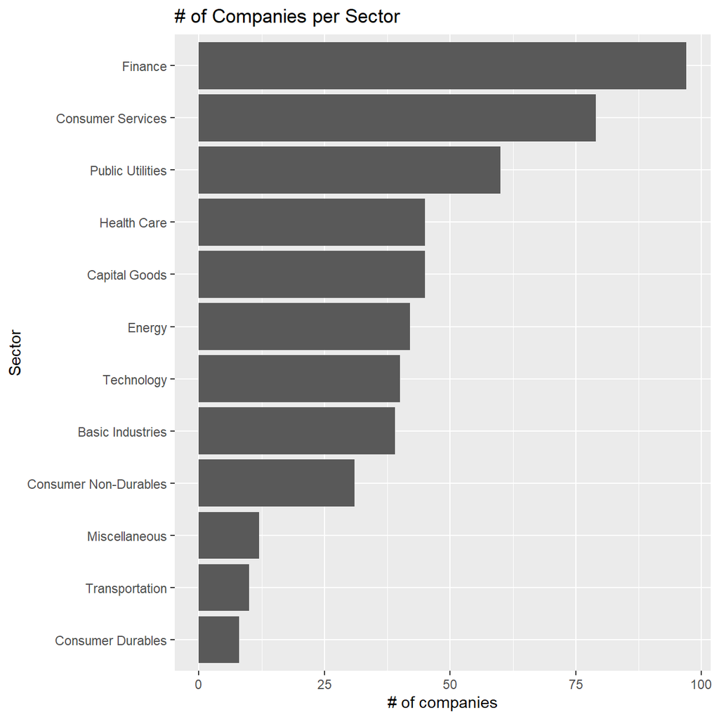

```r
#bar plot
ggplot(data = by_sector, mapping = aes(x = reorder(sector, count), y = count)) +
geom_col() +
coord_flip()+
labs(y= "# of companies", x = "Sector", title = "# of Companies per Sector")+
  NULL
```

Next, let’s choose the [Dow Jones Industrial Aveareg (DJIA)](https://en.wikipedia.org/wiki/Dow_Jones_Industrial_Average) stocks and their ticker symbols and download some data. Besides the thirty stocks that make up the DJIA, we will also add `SPY` which is an SP500 ETF (Exchange Traded Fund).

```r
djia_url <- "https://en.wikipedia.org/wiki/Dow_Jones_Industrial_Average"

tables <- djia_url %>%
  read_html() %>%
  html_nodes(css="table")


djia <- map(tables, . %>%
               html_table(fill=TRUE)%>%
               clean_names())


table1 <- djia[[2]] %>%
  mutate(date_added = ymd(date_added),


         ticker = ifelse(str_detect(symbol, "NYSE*"),
                          str_sub(symbol,7,11),
                          symbol)
         )

tickers <- table1 %>%
  select(ticker) %>%
  pull() %>%
  c("SPY")
```

```r
myStocks <- tickers %>%
  tq_get(get  = "stock.prices",
         from = "2000-01-01",
         to   = "2020-08-31") %>%
  group_by(symbol)

glimpse(myStocks)
```

```
## Rows: 153,121
## Columns: 8
## Groups: symbol [31]
## $ symbol   <chr> "MMM", "MMM", "MMM", "MMM", "MMM", "MMM", "MMM", "MMM", "M...
## $ date     <date> 2000-01-03, 2000-01-04, 2000-01-05, 2000-01-06, 2000-01-0...
## $ open     <dbl> 48.0, 46.4, 45.6, 47.2, 50.6, 50.2, 50.4, 51.0, 50.7, 50.4...
## $ high     <dbl> 48.2, 47.4, 48.1, 51.2, 51.9, 51.8, 51.2, 51.8, 50.9, 50.5...
## $ low      <dbl> 47.0, 45.3, 45.6, 47.2, 50.0, 50.0, 50.2, 50.4, 50.2, 49.5...
## $ close    <dbl> 47.2, 45.3, 46.6, 50.4, 51.4, 51.1, 50.2, 50.4, 50.4, 49.7...
## $ volume   <dbl> 2173400, 2713800, 3699400, 5975800, 4101200, 3863800, 2357...
## $ adjusted <dbl> 28.1, 26.9, 27.7, 30.0, 30.5, 30.4, 29.9, 30.0, 30.0, 29.5...
```

Financial performance analysis depend on returns; If I buy a stock today for 100 and I sell it tomorrow for 101.75, my one-day return, assuming no transaction costs, is 1.75%. So given the adjusted closing prices, our first step is to calculate daily and monthly returns.

```r
#calculate daily returns
myStocks_returns_daily <- myStocks %>%
  tq_transmute(select     = adjusted,
               mutate_fun = periodReturn,
               period     = "daily",
               type       = "log",
               col_rename = "daily_returns",
               cols = c(nested.col))

#calculate monthly  returns
myStocks_returns_monthly <- myStocks %>%
  tq_transmute(select     = adjusted,
               mutate_fun = periodReturn,
               period     = "monthly",
               type       = "arithmetic",
               col_rename = "monthly_returns",
               cols = c(nested.col))

#calculate yearly returns
myStocks_returns_annual <- myStocks %>%
  group_by(symbol) %>%
  tq_transmute(select     = adjusted,
               mutate_fun = periodReturn,
               period     = "yearly",
               type       = "arithmetic",
               col_rename = "yearly_returns",
               cols = c(nested.col))
```

Create a dataframe and assign it to a new object, where you summarise monthly returns since 2017-01-01 for each of the stocks and `SPY`; min, max, median, mean, SD.

```r
after_20170101 <- myStocks_returns_monthly %>%
    filter(date >= "2016-12-30")

after_20170101 %>%
  group_by(symbol) %>%
  summarise(Minimum_Perc = min(monthly_returns*100), Maximum_Perc = max(monthly_returns*100), Median_Perc = median(monthly_returns*100), Mean_Perc = mean(monthly_returns*100), Standard_Deviation_Perc = sd(monthly_returns*100))
```

```
## # A tibble: 31 x 6
##    symbol Minimum_Perc Maximum_Perc Median_Perc Mean_Perc Standard_Deviation_Pe~
##    <chr>         <dbl>        <dbl>       <dbl>     <dbl>                  <dbl>
##  1 AAPL          -18.1        20.0        4.87     3.89                     8.63
##  2 AMGN          -10.4        18.0        2.35     1.71                     6.56
##  3 AXP           -22.1         9.88       1.56     1.13                     6.32
##  4 BA            -45.8        25.7        2.72     1.29                    11.8
##  5 CAT           -19.9        13.8        3.14     1.41                     7.37
##  6 CRM           -15.5        39.1        4.02     3.32                     8.50
##  7 CSCO          -15.5        13.0        1.84     1.26                     6.65
##  8 CVX           -22.4        27.0        0.219    0.0318                   7.44
##  9 DIS           -17.9        23.4       -0.110    1.08                     7.46
## 10 DOW           -27.6        25.5        4.56     0.898                   12.8
## # ... with 21 more rows
```

Plot a density plot, using `geom_density()`, for each of the stocks

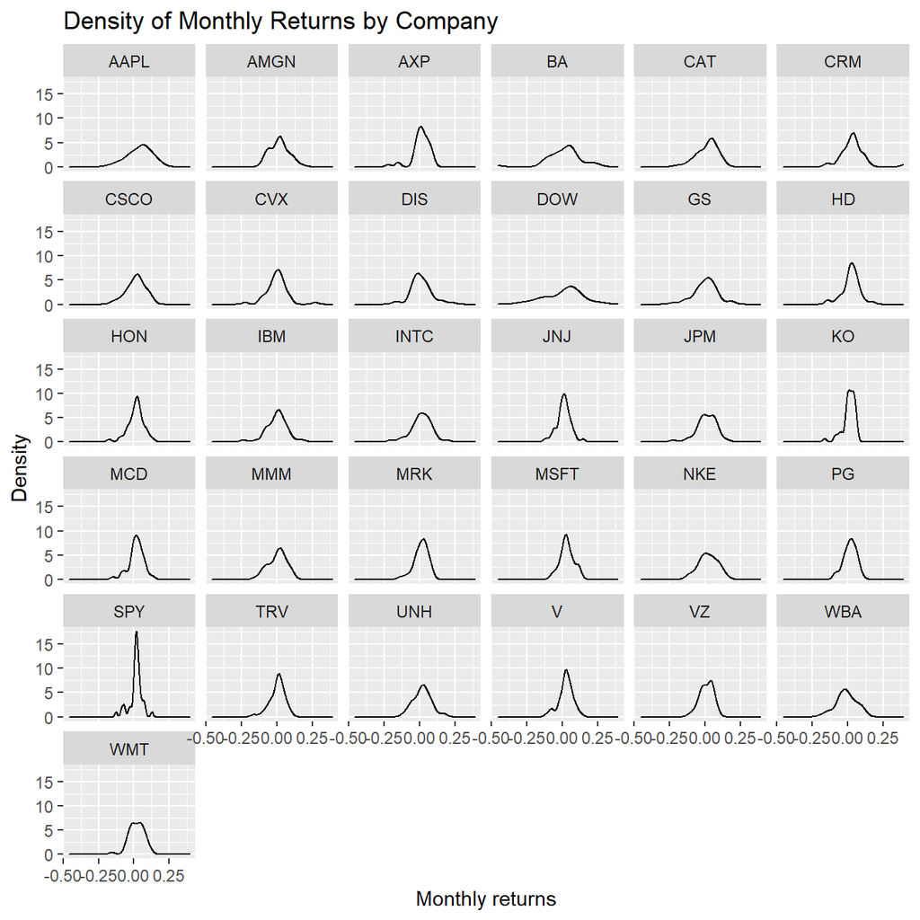

```r
# YOUR CODE GOES HERE
 ggplot(data = after_20170101, mapping = aes(x = monthly_returns)) +
     geom_density() +
     facet_wrap(~ symbol)+
     labs(y= "Density", x = "Monthly returns", title = "Density of Monthly Returns by Company")+
  NULL
```

Finally, produce a plot that shows the expected monthly return (mean) of a stock on the Y axis and the risk (standard deviation) in the X-axis. Please use `ggrepel::geom_text_repel()` to label each stock with its ticker symbol

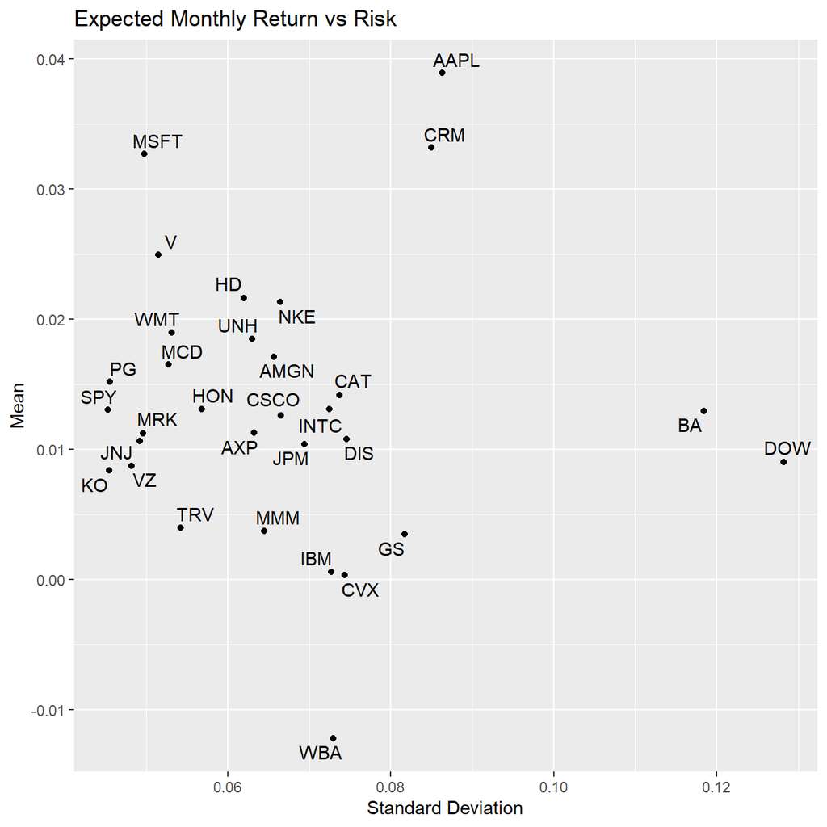

```r
 sd <- after_20170101 %>%
   group_by(symbol) %>%
  summarise(mean = mean(monthly_returns), SD = sd(monthly_returns))

ggplot(data = sd, mapping = aes(x = SD, y = mean, label = symbol)) +
  geom_point() +
  geom_text_repel()+
  labs(x = "Standard Deviation", y = "Mean", title = "Expected Monthly Return vs Risk")+
  NULL
```

What can you infer from this plot? Are there any stocks which, while being riskier, do not have a higher expected return?

Yes there are, Boeing for example has a significantly higher risk (as measured by SD) vs its mean monthly return. Cisco for example has a similar return profile whilst exhibiting lower risk

# 4 On your own: IBM HR Analytics

For this task, you will analyse a data set on Human Resoruce Analytics. The [IBM HR Analytics Employee Attrition & Performance data set](https://www.kaggle.com/pavansubhasht/ibm-hr-analytics-attrition-dataset) is a fictional data set created by IBM data scientists. Among other things, the data set includes employees’ income, their distance from work, their position in the company, their level of education, etc. A full description can be found on the website.

First let us load the data

```r
hr_dataset <- read_csv(here::here("data", "datasets_1067_1925_WA_Fn-UseC_-HR-Employee-Attrition.csv"))
glimpse(hr_dataset)
```

```
## Rows: 1,470
## Columns: 35
## $ Age                      <dbl> 41, 49, 37, 33, 27, 32, 59, 30, 38, 36, 35...
## $ Attrition                <chr> "Yes", "No", "Yes", "No", "No", "No", "No"...
## $ BusinessTravel           <chr> "Travel_Rarely", "Travel_Frequently", "Tra...
## $ DailyRate                <dbl> 1102, 279, 1373, 1392, 591, 1005, 1324, 13...
## $ Department               <chr> "Sales", "Research & Development", "Resear...
## $ DistanceFromHome         <dbl> 1, 8, 2, 3, 2, 2, 3, 24, 23, 27, 16, 15, 2...
## $ Education                <dbl> 2, 1, 2, 4, 1, 2, 3, 1, 3, 3, 3, 2, 1, 2, ...
## $ EducationField           <chr> "Life Sciences", "Life Sciences", "Other",...
## $ EmployeeCount            <dbl> 1, 1, 1, 1, 1, 1, 1, 1, 1, 1, 1, 1, 1, 1, ...
## $ EmployeeNumber           <dbl> 1, 2, 4, 5, 7, 8, 10, 11, 12, 13, 14, 15, ...
## $ EnvironmentSatisfaction  <dbl> 2, 3, 4, 4, 1, 4, 3, 4, 4, 3, 1, 4, 1, 2, ...
## $ Gender                   <chr> "Female", "Male", "Male", "Female", "Male"...
## $ HourlyRate               <dbl> 94, 61, 92, 56, 40, 79, 81, 67, 44, 94, 84...
```

[output cut: 22 more lines]

I am going to clean the data set, as variable names are in capital letters, some variables are not really necessary, and some variables, e.g., `education` are given as a number rather than a more useful description

```r
hr_cleaned <- hr_dataset %>%
  clean_names() %>%
  mutate(
    education = case_when(
      education == 1 ~ "Below College",
      education == 2 ~ "College",
      education == 3 ~ "Bachelor",
      education == 4 ~ "Master",
      education == 5 ~ "Doctor"
    ),
    environment_satisfaction = case_when(
      environment_satisfaction == 1 ~ "Low",
      environment_satisfaction == 2 ~ "Medium",
      environment_satisfaction == 3 ~ "High",
      environment_satisfaction == 4 ~ "Very High"
    ),
    job_satisfaction = case_when(
      job_satisfaction == 1 ~ "Low",
      job_satisfaction == 2 ~ "Medium",
      job_satisfaction == 3 ~ "High",
      job_satisfaction == 4 ~ "Very High"
    ),
    performance_rating = case_when(
      performance_rating == 1 ~ "Low",
      performance_rating == 2 ~ "Good",
      performance_rating == 3 ~ "Excellent",
      performance_rating == 4 ~ "Outstanding"
    ),
    work_life_balance = case_when(
      work_life_balance == 1 ~ "Bad",
      work_life_balance == 2 ~ "Good",
      work_life_balance == 3 ~ "Better",
      work_life_balance == 4 ~ "Best"
    )
  ) %>%
  select(age, attrition, daily_rate, department,
         distance_from_home, education,
         gender, job_role,environment_satisfaction,
         job_satisfaction, marital_status,
         monthly_income, num_companies_worked, percent_salary_hike,
         performance_rating, total_working_years,
         work_life_balance, years_at_company,
         years_since_last_promotion)
```

Produce a one-page summary describing this dataset. Here is a non-exhaustive list of questions:

1. How often do people leave the company (`attrition`)

```r
skim(hr_cleaned)
```

Data summary

| Name | hr_cleaned |
| --- | --- |
| Number of rows | 1470 |
| Number of columns | 19 |
| _______________________ |  |
| Column type frequency: |  |
| character | 10 |
| numeric | 9 |
| ________________________ |  |
| Group variables | None |

**Variable type: character**

| skim_variable | n_missing | complete_rate | min | max | empty | n_unique | whitespace |
| --- | --- | --- | --- | --- | --- | --- | --- |
| attrition | 0 | 1 | 2 | 3 | 0 | 2 | 0 |
| department | 0 | 1 | 5 | 22 | 0 | 3 | 0 |
| education | 0 | 1 | 6 | 13 | 0 | 5 | 0 |
| gender | 0 | 1 | 4 | 6 | 0 | 2 | 0 |
| job_role | 0 | 1 | 7 | 25 | 0 | 9 | 0 |
| environment_satisfaction | 0 | 1 | 3 | 9 | 0 | 4 | 0 |
| job_satisfaction | 0 | 1 | 3 | 9 | 0 | 4 | 0 |
| marital_status | 0 | 1 | 6 | 8 | 0 | 3 | 0 |
| performance_rating | 0 | 1 | 9 | 11 | 0 | 2 | 0 |
| work_life_balance | 0 | 1 | 3 | 6 | 0 | 4 | 0 |

**Variable type: numeric**

| skim_variable | n_missing | complete_rate | mean | sd | p0 | p25 | p50 | p75 | p100 | hist |
| --- | --- | --- | --- | --- | --- | --- | --- | --- | --- | --- |
| age | 0 | 1 | 36.92 | 9.14 | 18 | 30 | 36 | 43 | 60 | ▂▇▇▃▂ |
| daily_rate | 0 | 1 | 802.49 | 403.51 | 102 | 465 | 802 | 1157 | 1499 | ▇▇▇▇▇ |
| distance_from_home | 0 | 1 | 9.19 | 8.11 | 1 | 2 | 7 | 14 | 29 | ▇▅▂▂▂ |
| monthly_income | 0 | 1 | 6502.93 | 4707.96 | 1009 | 2911 | 4919 | 8379 | 19999 | ▇▅▂▁▂ |
| num_companies_worked | 0 | 1 | 2.69 | 2.50 | 0 | 1 | 2 | 4 | 9 | ▇▃▂▂▁ |
| percent_salary_hike | 0 | 1 | 15.21 | 3.66 | 11 | 12 | 14 | 18 | 25 | ▇▅▃▂▁ |
| total_working_years | 0 | 1 | 11.28 | 7.78 | 0 | 6 | 10 | 15 | 40 | ▇▇▂▁▁ |
| years_at_company | 0 | 1 | 7.01 | 6.13 | 0 | 3 | 5 | 9 | 40 | ▇▂▁▁▁ |
| years_since_last_promotion | 0 | 1 | 2.19 | 3.22 | 0 | 0 | 1 | 3 | 15 | ▇▁▁▁▁ |

```r
Countattrition <- hr_cleaned %>%
             group_by(attrition) %>%
             count()
AttritionRate <-  (Countattrition[2,2]/(Countattrition[1,2]+Countattrition[2,2]))
AttritionRate
```

```
##       n
## 1 0.161
```

That means 16,1% of employers leave the company. No N/A values

2. How are `age`, `years_at_company`, `monthly_income` and `years_since_last_promotion` distributed? can you roughly guess which of these variables is closer to Normal just by looking at summary statistics?

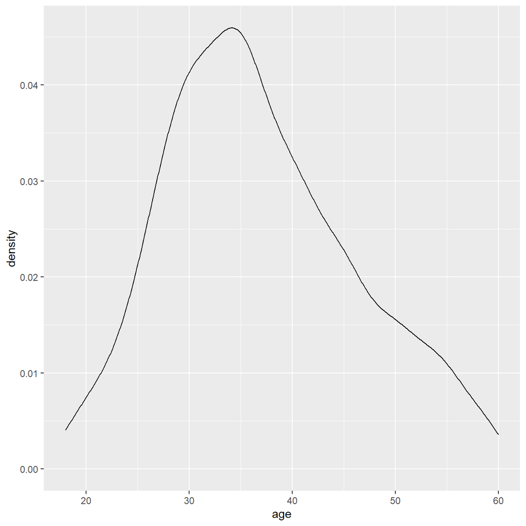

```r
 ggplot(hr_cleaned, aes(x = age))+
 geom_density()
```

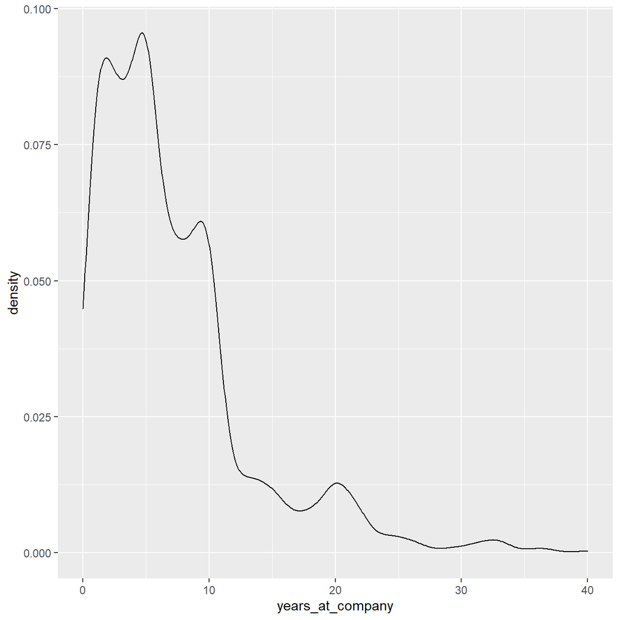

```r
 ggplot(hr_cleaned, aes(x = years_at_company))+
 geom_density()
```

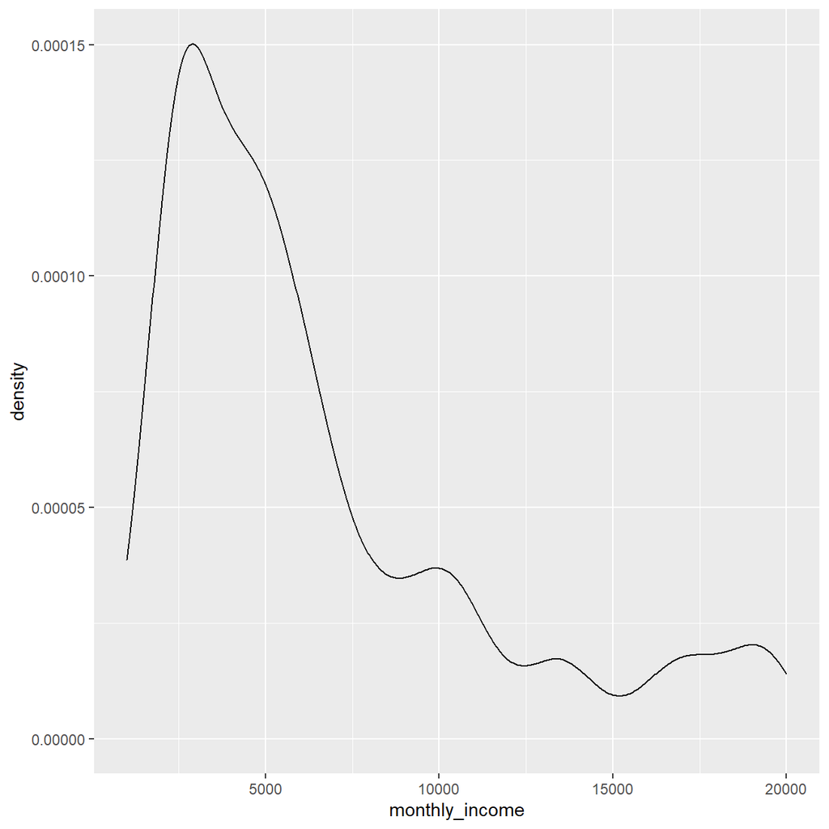

```r
  ggplot(hr_cleaned, aes(x = monthly_income))+
 geom_density()
```

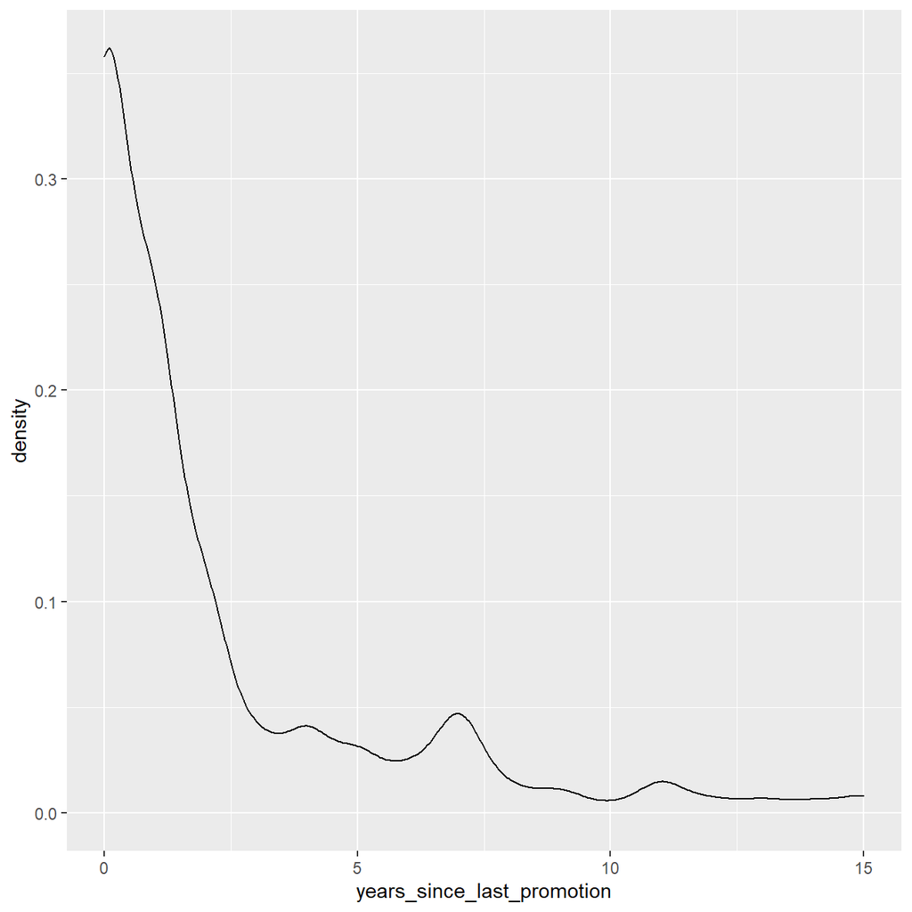

```r
  ggplot(hr_cleaned, aes(x = years_since_last_promotion))+
 geom_density()
```

Based on the plots, age is the closest to a normal distribution, although it seems to be positively skewed.

3. How are `job_satisfaction` and `work_life_balance` distributed? Don’t just report counts, but express categories as % of total

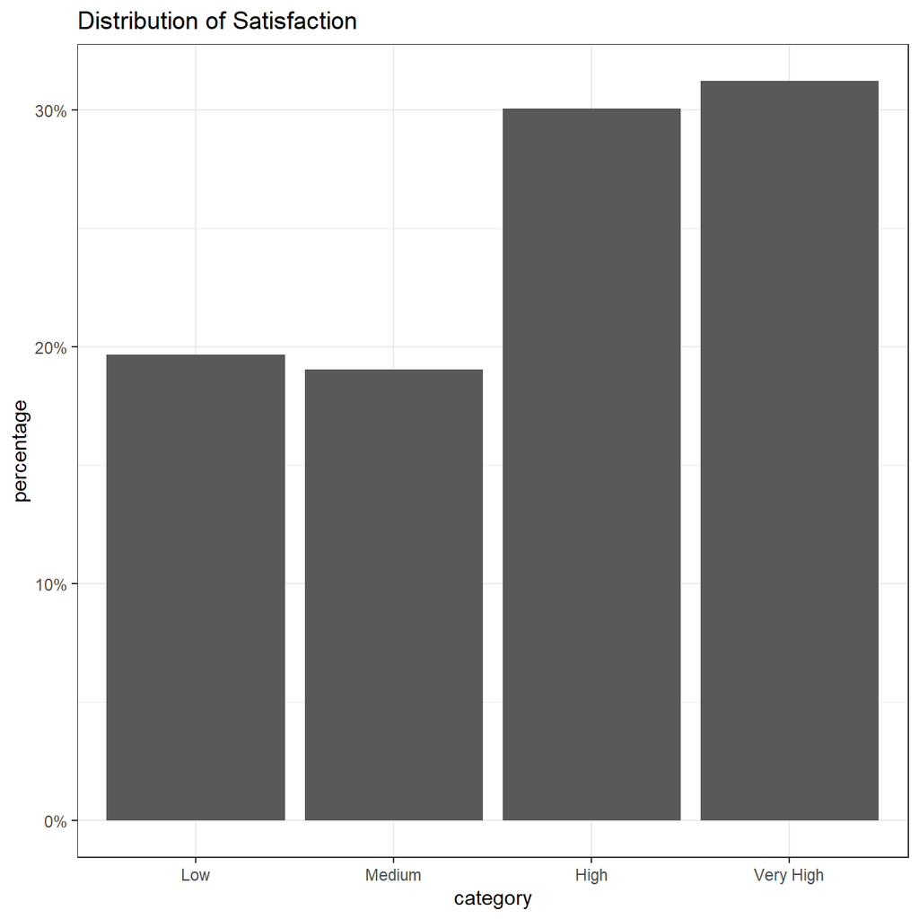

```r
Satisfaction <- hr_cleaned %>%
                 group_by(job_satisfaction) %>%
                 count()
colnames(Satisfaction) <- c("job_satisfaction", "count")
Satisfaction$Percentage <- Satisfaction$count/sum(Satisfaction$count)
Satisfaction$job_satisfaction = factor(Satisfaction$job_satisfaction, levels = c("Low","Medium","High","Very High"))
ggplot(Satisfaction, aes(x = job_satisfaction, y= Percentage)) + geom_bar(stat="identity") +
   scale_y_continuous(labels=scales::percent) +
  labs(title = "Distribution of Satisfaction", x="category", y="percentage") +
  theme_bw()
```

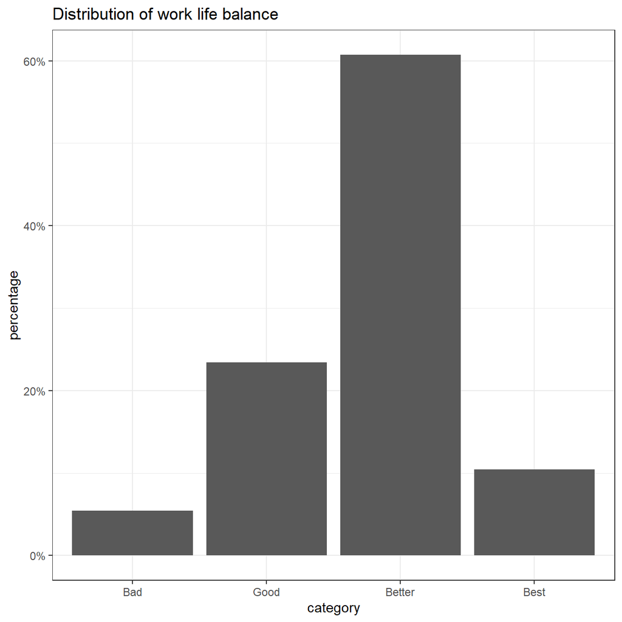

```r
WorkBalance <- hr_cleaned %>%
                 group_by(work_life_balance) %>%
                 count()
colnames(WorkBalance) <- c("work_life_balance", "count")
WorkBalance$Percentage <- WorkBalance$count/sum(WorkBalance$count)
WorkBalance$work_life_balance = factor(WorkBalance$work_life_balance, levels = c("Bad","Good","Better","Best"))

ggplot(WorkBalance, aes(x = work_life_balance, y= Percentage)) + geom_bar(stat="identity") +
   scale_y_continuous(labels=scales::percent) +
  labs(title = "Distribution of work life balance", x="category", y="percentage") +
  theme_bw()
```

4. Is there any relationship between monthly income and education? Monthly income and gender?

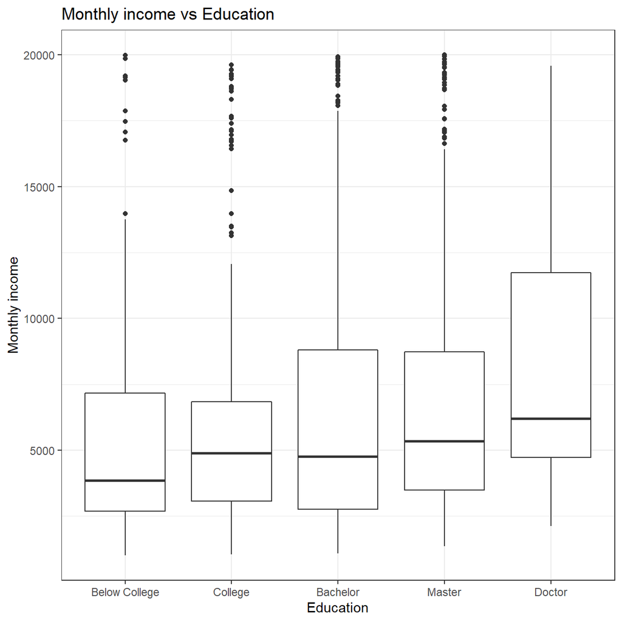

```r
hr_cleaned$education = factor(hr_cleaned$education, levels = c("Below College","College","Bachelor","Master","Doctor"))

ggplot(hr_cleaned, aes(x=education, y=monthly_income)) + geom_boxplot() + labs(title = "Monthly income vs Education", x="Education", y="Monthly income") + theme_bw()
```

[figure not shown]

```r
ggplot(hr_cleaned, aes(x=gender, y = monthly_income)) + geom_boxplot()  + labs(title = "Monthly income vs Educationr", x="Gender", y="Monthly income") + theme_bw()
```

5. Plot a boxplot of income vs job role. Make sure the highest-paid job roles appear first

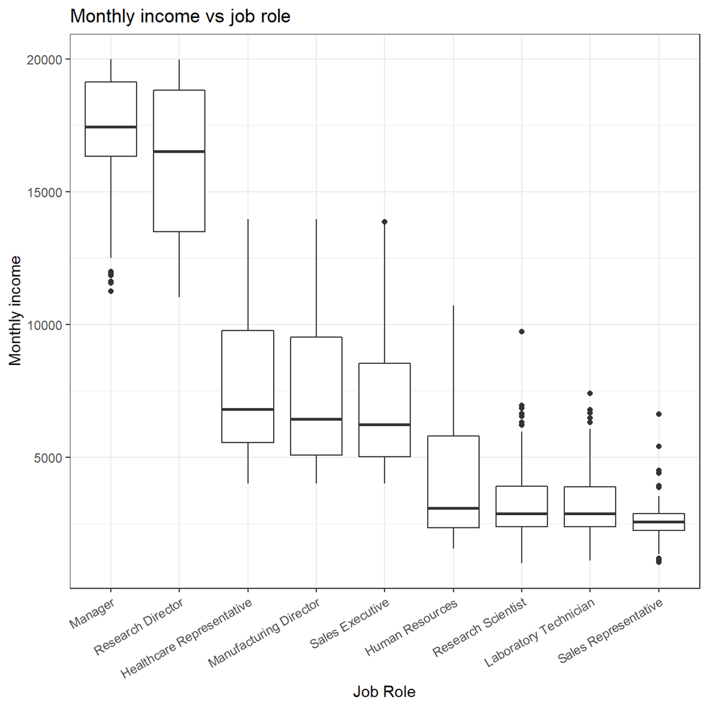

```r
ggplot(hr_cleaned, aes(y=monthly_income)) + geom_boxplot(aes(x=reorder(job_role, -monthly_income)))  + labs(title = "Monthly income vs job role", x="Job Role", y="Monthly income") + theme_bw() + theme(axis.text.x = element_text(angle = 30, hjust = 1))
```

Monthly income varies considerably between roles, therefore, Managers have the best income while sales representatives have the smaller income.

6. Calculate and plot a bar chart of the mean (or median?) income by education level.

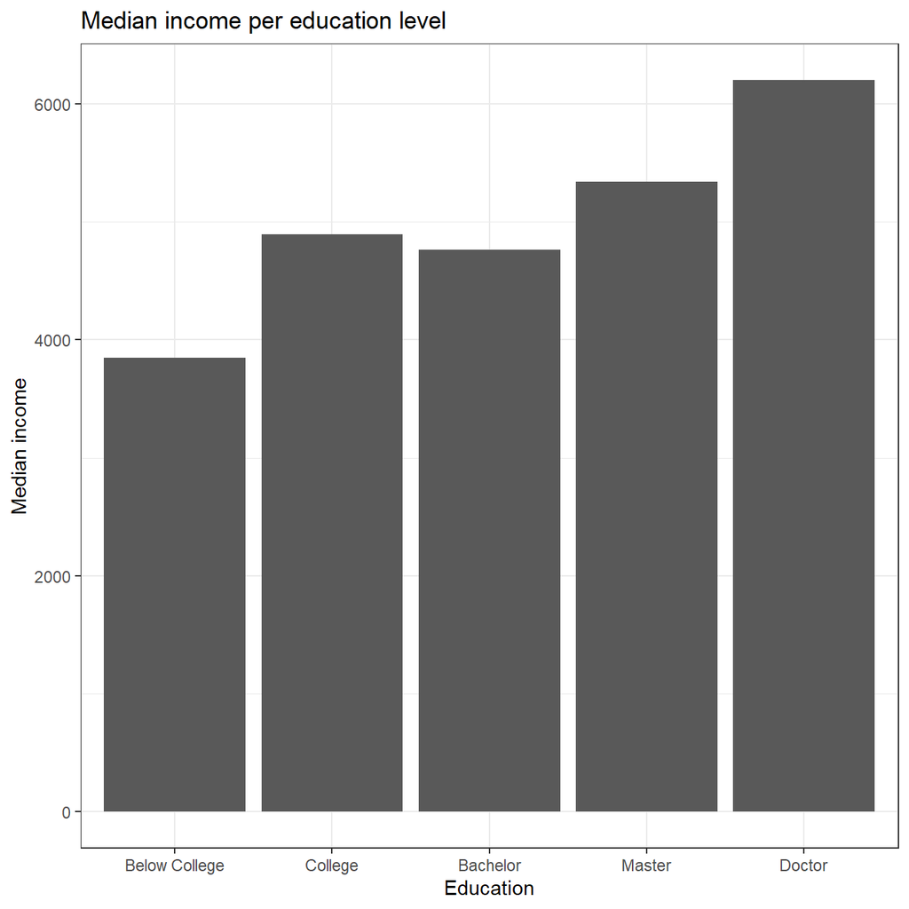

```r
EducationMedian <- hr_cleaned %>%
  group_by(education) %>%
  summarise(Median_Income=median(monthly_income))

ggplot(EducationMedian, aes(x=education, y=Median_Income)) + geom_col()  + labs(title = "Median income per education level", x="Education", y="Median income") + theme_bw()
```

7. Plot the distribution of income by education level. Use a facet_wrap and a theme from `ggthemes`

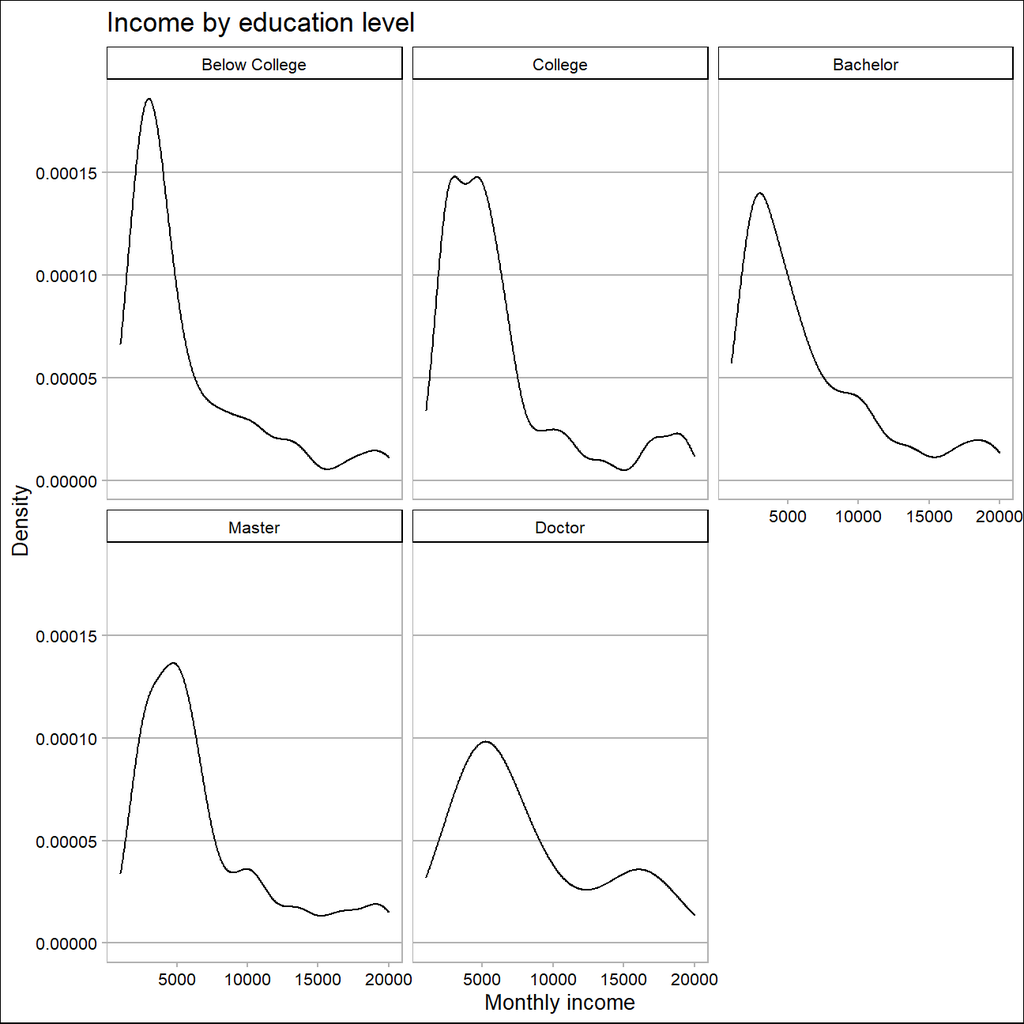

```r
 ggplot(hr_cleaned, aes(x = monthly_income))+
 geom_density()+
 facet_wrap(~education)+
 labs(title = "Income by education level", x="Monthly income", y="Density")+
 theme_calc()
```

1. Plot income vs age, faceted by `job_role`

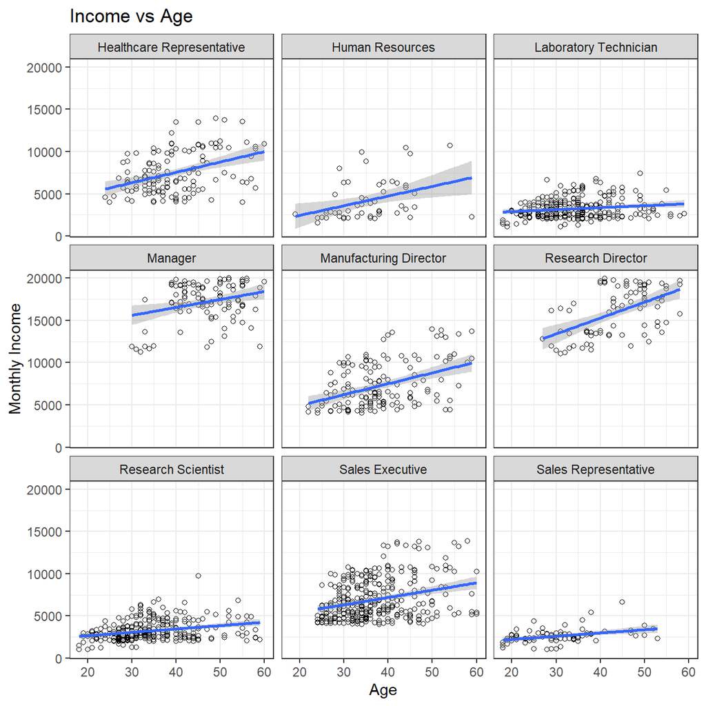

```r
ggplot(hr_cleaned, aes(x=age, y=monthly_income)) +
    labs(title = "Income vs Age", x="Age", y="Monthly Income") +
    geom_point(shape=1) +
    facet_wrap(~job_role)+
    geom_smooth(method=lm)+
     theme_bw()
```

Infer from the graphics that Age and Monthly Income have a positive correlation, because income tends to increase when worker get older. It makes sense, since you can assume that job seniority and responsibilities tend to increase with age.

# 5 Challenge 1: Replicating a chart

The purpose of this exercise is to make a publication-ready plot using your `dplyr` and `ggplot2` skills. Open the journal article “Riddell_Annals_Hom-Sui-Disparities.pdf”. Read the abstract and have a look at Figure 3. The data you need is “CDC_Males.csv”.

Don’t worry about replicating it exactly, try and see how far you can get. You’re encouraged to work together if you want to and exchange tips/tricks you figured out.

You may find these helpful:

- https://cran.r-project.org/web/packages/ggrepel/vignettes/ggrepel.html
- http://colorbrewer2.org

Data summary

| Name | CDC_Males |
| --- | --- |
| Number of rows | 104 |
| Number of columns | 28 |
| _______________________ |  |
| Column type frequency: |  |
| character | 7 |
| numeric | 21 |
| ________________________ |  |
| Group variables | None |

**Variable type: character**

| skim_variable | n_missing | complete_rate | min | max | empty | n_unique | whitespace |
| --- | --- | --- | --- | --- | --- | --- | --- |
| ST | 0 | 1.00 | 2 | 2 | 0 | 52 | 0 |
| State | 0 | 1.00 | 4 | 20 | 0 | 52 | 0 |
| type | 0 | 1.00 | 7 | 11 | 0 | 2 | 0 |
| ST.order.RD.homicide | 0 | 1.00 | 2 | 2 | 0 | 52 | 0 |
| ST.order.RD.suicide | 0 | 1.00 | 2 | 2 | 0 | 52 | 0 |
| gun.house.prev.category | 4 | 0.96 | 11 | 11 | 0 | 4 | 0 |
| type.fac | 0 | 1.00 | 15 | 17 | 0 | 2 | 0 |

**Variable type: numeric**

| skim_variable | n_missing | complete_rate | mean | sd | p0 | p25 | p50 | p75 | p100 | hist |
| --- | --- | --- | --- | --- | --- | --- | --- | --- | --- | --- |
| Population.Black | 2 | 0.98 | 3.41e+06 | 3.95e+06 | 4.05e+04 | 3.07e+05 | 1.47e+06 | 5.98e+06 | 1.35e+07 | ▇▂▂▁▁ |
| Population.White | 2 | 0.98 | 1.74e+07 | 1.53e+07 | 1.01e+06 | 5.69e+06 | 1.35e+07 | 2.28e+07 | 6.93e+07 | ▇▃▁▁▁ |
| Deaths.homicide.Black | 21 | 0.80 | 1.43e+03 | 5.94e+03 | 1.10e+01 | 7.75e+01 | 2.47e+02 | 1.34e+03 | 5.38e+04 | ▇▁▁▁▁ |
| Deaths.homicide.White | 2 | 0.98 | 4.83e+02 | 1.91e+03 | 1.00e+01 | 5.42e+01 | 1.40e+02 | 3.83e+02 | 1.84e+04 | ▇▁▁▁▁ |
| crude.homicide.Black | 26 | 0.75 | 1.78e+01 | 1.61e+01 | 1.70e+00 | 3.47e+00 | 1.48e+01 | 2.93e+01 | 6.27e+01 | ▇▃▃▁▁ |
| crude.homicide.White | 10 | 0.90 | 1.47e+00 | 1.13e+00 | 2.70e-01 | 7.00e-01 | 1.01e+00 | 1.90e+00 | 4.74e+00 | ▇▂▁▁▁ |
| adjusted.homicide.Black | 26 | 0.75 | 1.68e+01 | 1.52e+01 | 1.68e+00 | 3.48e+00 | 1.29e+01 | 2.78e+01 | 5.94e+01 | ▇▃▃▁▁ |
| adjusted.homicide.White | 10 | 0.90 | 1.50e+00 | 1.17e+00 | 2.40e-01 | 6.70e-01 | 9.90e-01 | 1.98e+00 | 4.79e+00 | ▇▂▁▁▁ |
| Deaths.suicide.Black | 19 | 0.82 | 3.88e+02 | 1.25e+03 | 1.10e+01 | 5.70e+01 | 1.20e+02 | 3.23e+02 | 8.93e+03 | ▇▁▁▁▁ |
| Deaths.suicide.White | 0 | 1.00 | 4.53e+03 | 1.63e+04 | 2.30e+01 | 7.20e+02 | 1.73e+03 | 3.37e+03 | 1.39e+05 | ▇▁▁▁▁ |
| crude.suicide.Black | 26 | 0.75 | 5.35e+00 | 2.00e+00 | 1.62e+00 | 4.24e+00 | 5.24e+00 | 6.33e+00 | 1.50e+01 | ▃▇▁▁▁ |
| crude.suicide.White | 0 | 1.00 | 1.38e+01 | 5.52e+00 | 2.27e+00 | 1.01e+01 | 1.22e+01 | 1.71e+01 | 2.96e+01 | ▁▇▃▃▁ |
| adjusted.suicide.Black | 26 | 0.75 | 5.43e+00 | 1.87e+00 | 1.79e+00 | 4.33e+00 | 5.41e+00 | 6.41e+00 | 1.28e+01 | ▃▇▅▁▁ |
| adjusted.suicide.White | 0 | 1.00 | 1.32e+01 | 5.06e+00 | 2.35e+00 | 9.72e+00 | 1.18e+01 | 1.62e+01 | 2.86e+01 | ▁▇▃▂▁ |
| crude.RD.suicide | 26 | 0.75 | -8.37e+00 | 4.30e+00 | -1.93e+01 | -1.09e+01 | -6.85e+00 | -5.45e+00 | 1.78e+00 | ▂▃▅▇▁ |
| adj.RD.suicide | 26 | 0.75 | -7.55e+00 | 3.63e+00 | -1.56e+01 | -9.84e+00 | -6.50e+00 | -5.26e+00 | 1.83e+00 | ▃▃▇▃▁ |
| crude.RD.homicide | 28 | 0.73 | 1.59e+01 | 1.51e+01 | 1.11e+00 | 2.72e+00 | 1.25e+01 | 2.63e+01 | 6.00e+01 | ▇▃▃▁▁ |
| adj.RD.homicide | 28 | 0.73 | 1.49e+01 | 1.42e+01 | 1.27e+00 | 2.77e+00 | 1.11e+01 | 2.38e+01 | 5.66e+01 | ▇▃▂▁▁ |
| gun.house.prev | 4 | 0.96 | 3.90e+01 | 1.41e+01 | 1.02e+01 | 3.23e+01 | 4.03e+01 | 4.65e+01 | 6.55e+01 | ▃▂▇▅▃ |
| average.pop.white | 2 | 0.98 | 1.94e+06 | 1.70e+06 | 1.13e+05 | 6.33e+05 | 1.50e+06 | 2.53e+06 | 7.70e+06 | ▇▃▁▁▁ |
| average.pop.black | 2 | 0.98 | 3.78e+05 | 4.38e+05 | 4.50e+03 | 3.41e+04 | 1.64e+05 | 6.65e+05 | 1.51e+06 | ▇▂▂▁▁ |

```
## Rows: 104
## Columns: 28
## $ ST                      <chr> "AK", "AK", "AL", "AL", "AR", "AR", "AZ", "...
## $ State                   <chr> "Alaska", "Alaska", "Alabama", "Alabama", "...
## $ Population.Black        <dbl> 153664, 153664, 5376635, 5376635, 1991165, ...
## $ Population.White        <dbl> 2274605, 2274605, 14267619, 14267619, 97470...
## $ Deaths.homicide.Black   <dbl> 23, NA, 183, 1812, 667, 90, 300, 40, 3712, ...
## $ Deaths.homicide.White   <dbl> 78, 10, 124, 620, 416, 110, 586, 145, 1399,...
## $ crude.homicide.Black    <dbl> 14.97, NA, 3.40, 33.70, 33.50, 4.52, 22.06,...
## $ crude.homicide.White    <dbl> 3.43, NA, 0.87, 4.35, 4.27, 1.13, 3.46, 0.8...
## $ adjusted.homicide.Black <dbl> 12.30, NA, 3.51, 33.00, 33.39, 4.81, 20.40,...
## $ adjusted.homicide.White <dbl> 3.24, NA, 0.85, 4.47, 4.39, 1.13, 3.63, 0.9...
## $ Deaths.suicide.Black    <dbl> 23, 12, 148, 370, 118, 75, 101, 80, 492, 63...
## $ Deaths.suicide.White    <dbl> 535, 196, 1222, 3195, 2154, 1027, 4146, 197...
## $ crude.suicide.Black     <dbl> 14.97, NA, 2.75, 6.88, 5.93, 3.77, 7.43, 5....
## $ crude.suicide.White     <dbl> 23.52, 8.62, 8.56, 22.39, 22.10, 10.54, 24....
## $ adjusted.suicide.Black  <dbl> 12.77, NA, 2.84, 7.20, 6.25, 3.93, 7.51, 5....
## $ adjusted.suicide.White  <dbl> 23.47, 8.21, 8.64, 20.97, 20.98, 10.89, 21....
## $ type                    <chr> "Firearm", "Non-Firearm", "Non-Firearm", "F...
## $ crude.RD.suicide        <dbl> -8.55, NA, -5.81, -15.51, -16.17, -6.77, -1...
## $ adj.RD.suicide          <dbl> -10.70, NA, -5.80, -13.77, -14.73, -6.96, -...
## $ crude.RD.homicide       <dbl> 11.54, NA, 2.53, 29.35, 29.23, 3.39, 18.60,...
## $ adj.RD.homicide         <dbl> 9.06, NA, 2.66, 28.53, 29.00, 3.68, 16.77, ...
## $ ST.order.RD.homicide    <chr> "AK", "AK", "AL", "AL", "AR", "AR", "AZ", "...
## $ ST.order.RD.suicide     <chr> "AK", "AK", "AL", "AL", "AR", "AR", "AZ", "...
## $ gun.house.prev          <dbl> 59.8, 59.8, 52.2, 52.2, 58.8, 58.8, 32.3, 3...
## $ gun.house.prev.category <chr> "45.0%-65.5%", "45.0%-65.5%", "45.0%-65.5%"...
## $ average.pop.white       <dbl> 252734, 252734, 1585291, 1585291, 1083003, ...
## $ average.pop.black       <dbl> 17074, 17074, 597404, 597404, 221241, 22124...
## $ type.fac                <chr> "Firearm-related", "Firearm-unrelated", "Fi...
```

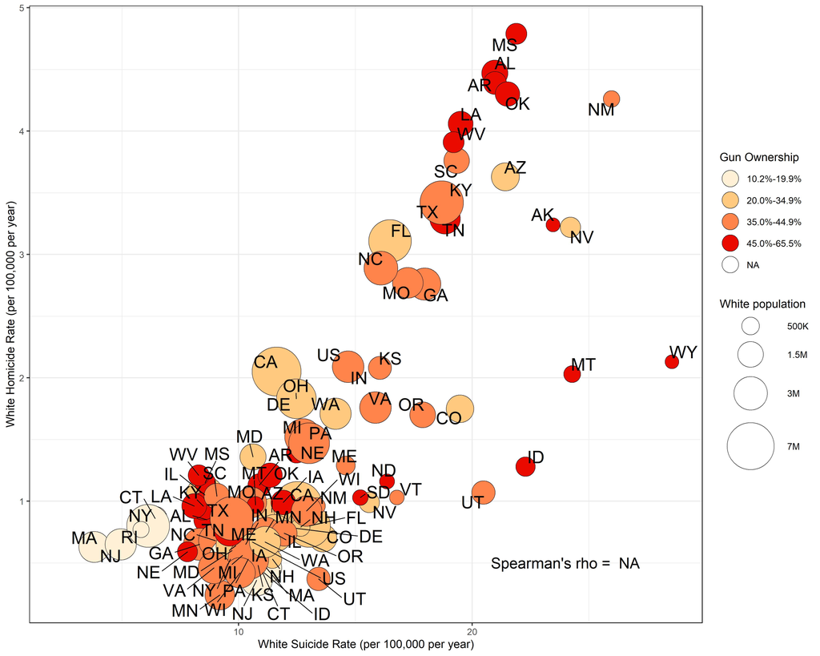

# 6 Challenge 2: 2016 California Contributors plots

As discussed in class, I would like you to reproduce the plot that shows the top ten cities in highest amounts raised in political contributions in California during the 2016 US Presidential election.

To get this plot, you must join two dataframes; the one you have with all contributions, and data that can translate zipcodes to cities. You can find a file with all US zipcodes, e.g., here http://www.uszipcodelist.com/download.html.

The easiest way would be to create two plots and then place one next to each other. For this, you will need the `patchwork` package. https://cran.r-project.org/web/packages/patchwork/index.html

While this is ok, what if one asked you to create the same plot for the top 10 candidates and not just the top two? The most challenging part is how to reorder within categories, and for this you will find Julia Silge’s post on [REORDERING AND FACETTING FOR GGPLOT2](https://juliasilge.com/blog/reorder-within/) useful.

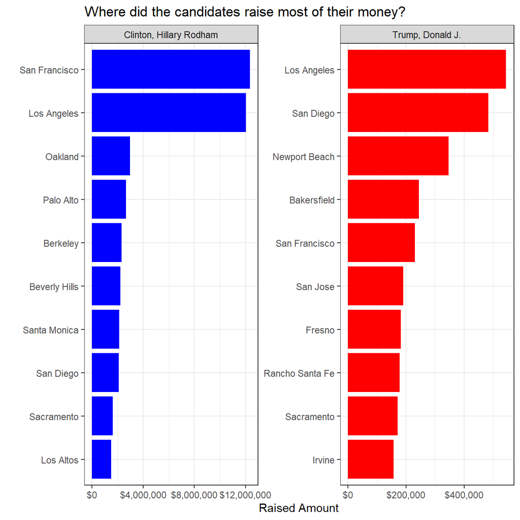

```r
CA_contributors_2016 <- vroom::vroom(here::here("data","CA_contributors_2016.csv"))
Zip_codes <- vroom::vroom(here::here("data","zip_code_database.csv"))

Zip_codes_clean <- filter(Zip_codes, state == "CA")

Cali_contributors <- CA_contributors_2016 %>%
  filter(cand_nm %in% c("Clinton, Hillary Rodham","Trump, Donald J."))

joint_zip <- merge(Cali_contributors, Zip_codes_clean, "zip")

new_data <- joint_zip %>%
  group_by(cand_nm) %>%
  count(primary_city, wt = contb_receipt_amt, sort = TRUE)

new_data %>%
  group_by(cand_nm) %>%
  top_n(10) %>%
  ungroup %>%
  mutate(cand_nm = factor(cand_nm),
    primary_city = reorder_within(primary_city, n, cand_nm)) %>%
  ggplot(aes(x = primary_city, y = n, fill = cand_nm)) +
  geom_col(show.legend = FALSE) +

  scale_fill_manual(values = c("Clinton, Hillary Rodham" = "blue","Trump, Donald J." = "red")) +
  facet_wrap(~cand_nm, scales = 'free') +
  scale_x_reordered() +
  scale_y_continuous(labels = label_dollar()) +
  theme_bw() +
  labs(y = "Raised Amount",
       x = "",
       title = "Where did the candidates raise most of their money?") +
  coord_flip()
```

[figure not shown]

```r
CA_contributors_top10 <- CA_contributors_2016 %>%
  group_by(cand_nm) %>%
  summarise(total_contr = sum(contb_receipt_amt)) %>%
  arrange(desc(total_contr)) %>%
  head(10)
top10_contributors <- CA_contributors_top10$cand_nm

Cali_top_10 <- CA_contributors_2016 %>%
  filter(cand_nm %in% top10_contributors)

merged_top_10 <- merge(Cali_top_10,Zip_codes_clean,"zip")


total_data <- merged_top_10 %>%
  group_by(cand_nm) %>%
  count(primary_city, wt = contb_receipt_amt, sort = TRUE)

candm_shade <- c("Bush, Jeb"  = "red",
                 "Carson, Benjamin S." ="red",
                 "Clinton, Hillary Rodham" = "blue",
                 "Cruz, Rafael Edward 'Ted'" ="red",
                 "Fiorina, Carly" ="red",
                 "Kasich, John R." ="red",
                 "Paul, Rand" ="red",
                 "Rubio, Marco" ="red",
                 "Sanders, Bernard" = "blue",
                 "Trump, Donald J." = "red")

total_data %>%
  group_by(cand_nm) %>%
  top_n(10) %>%
  ungroup %>%
  mutate(cand_nm = factor(cand_nm),
    primary_city = reorder_within(primary_city, n, cand_nm)) %>%
  ggplot(aes(x = primary_city, y = n, fill = cand_nm)) +
  geom_col(show.legend = FALSE) +
  scale_fill_manual(values = candm_shade) +
  facet_wrap(~cand_nm, scales = "free",nrow = 4, ncol = 3) +
  scale_x_reordered() +
  scale_y_continuous(labels = label_dollar()) +
  theme_bw() +
  labs(y = "Raised Amount",
       x = "",
       title = "Where did the Top 10 presidential candidates raise the highest contributions?") +
  coord_flip()
```

# 7 Deliverables

There is a lot of explanatory text, comments, etc. You do not need these, so delete them and produce a stand-alone document that you could share with someone. Knit the edited and completed R Markdown file as an HTML document (use the “Knit” button at the top of the script editor window) and upload it to Canvas.

# 8 Details

- Who did you collaborate with: All of Group A14
- Approximately how much time did you spend on this problem set: 2-3 days
- What, if anything, gave you the most trouble: Plots

**Please seek out help when you need it,** and remember the [15-minute rule](https://mam2021.netlify.app/syllabus/#the-15-minute-rule). You know enough R (and have enough examples of code from class and your readings) to be able to do this. If you get stuck, ask for help from others, post a question on Slack– and remember that I am here to help too!

> As a true test to yourself, do you understand the code you submitted and are you able to explain it to someone else?

# 9 Rubric

Check minus (1/5): Displays minimal effort. Doesn’t complete all components. Code is poorly written and not documented. Uses the same type of plot for each graph, or doesn’t use plots appropriate for the variables being analyzed.

Check (3/5): Solid effort. Hits all the elements. No clear mistakes. Easy to follow (both the code and the output).

Check plus (5/5): Finished all components of the assignment correctly and addressed both challenges. Code is well-documented (both self-documented and with additional comments as necessary). Used tidyverse, instead of base R. Graphs and tables are properly labelled. Analysis is clear and easy to follow, either because graphs are labeled clearly or you’ve written additional text to describe how you interpret the output.